# Risk of recidivism analysis

## Setup

```r
if (!require("pacman")) install.packages("pacman")
```

```r
pacman::p_load(
 tidyverse, # tidyverse packages
 conflicted, # an alternative conflict resolution strategy
 patchwork, # arranging ggplots
 scales, # rescaling
 survival, # survival analysis
 broom, # for modeling
 here, # reproducibility
 glue # pasting strings and objects
)

# To avoid conflicts
conflict_prefer("filter", "dplyr")
```

```
## [conflicted] Will prefer dplyr::filter over any other package
```

```r
conflict_prefer("select", "dplyr")
```

```
## [conflicted] Will prefer dplyr::select over any other package
```

## Load data

We select fields for severity of charge, number of priors, demographics, age, sex, COMPAS scores, and whether each person was accused of a crime within two years.

- N of observations (rows): 7,214
- N of variables (columns): 53

```r
two_years <- read_csv(here("data", "compas-scores-two-years.csv"))
dim(two_years)
```

```
## [1] 7214   53
```

## Wrangling

- Not all of the observations are useable for the first round of analysis.
- There are a number of reasons to remove rows because of missing data:
  - If the charge date of a defendants COMPAS scored crime was not within 30 days from when the person was arrested, we assume that because of data quality reasons, that we do not have the right offense.
  - We coded the recidivist flag – is_recid – to be -1 if we could not find a COMPAS case at all.
  - In a similar vein, ordinary traffic offenses – those with a c_charge_degree of ‘O’ – will not result in Jail time are removed (only two of them).
  - We filtered the underlying data from Broward county to include only those rows representing people who had either recidivated in two years, or had at least two years outside of a correctional facility.

### Create a function

```r
wrangle_data <- function(data){

df <- data %>%

    # Select variables
    select(age, c_charge_degree, race, age_cat, score_text, sex, priors_count, days_b_screening_arrest, decile_score, is_recid, two_year_recid,
         c_jail_in, c_jail_out) %>%
    # Filter rows
    filter(days_b_screening_arrest <= 30,
           days_b_screening_arrest >= -30,
           is_recid != -1,
           c_charge_degree != "O",
           score_text != 'N/A') %>%
    # Mutate variables
    mutate(length_of_stay = as.numeric(as.Date(c_jail_out) - as.Date(c_jail_in)),
           c_charge_degree = factor(c_charge_degree),
           age_cat = factor(age_cat),
           race = factor(race, levels = c("Caucasian","African-American","Hispanic","Other","Asian","Native American")),
           sex = factor(sex, levels = c("Male","Female")),
           score_text = factor(score_text, levels = c("Low", "Medium", "High")),
           score = score_text,
# I added this new variable to test whether measuring the DV as a binary or continuous var makes a difference
           score_num = as.numeric(score_text)) %>%
    # Rename variables
    rename(crime = c_charge_degree,
           gender = sex)

return(df)}
```

### Apply the function to the data

```r
df <- wrangle_data(two_years)

names(df)
```

```
##  [1] "age"                     "crime"
##  [3] "race"                    "age_cat"
##  [5] "score_text"              "gender"
##  [7] "priors_count"            "days_b_screening_arrest"
##  [9] "decile_score"            "is_recid"
## [11] "two_year_recid"          "c_jail_in"
## [13] "c_jail_out"              "length_of_stay"
## [15] "score"                   "score_num"
```

```r
# Check whether the function works as expected
head(df, 5)
```

```
## # A tibble: 5 x 16
##     age crime race  age_cat score_text gender priors_count days_b_screenin…
##   <dbl> <fct> <fct> <fct>   <fct>      <fct>         <dbl>            <dbl>
## 1    69 F     Other Greate… Low        Male              0               -1
## 2    34 F     Afri… 25 - 45 Low        Male              0               -1
## 3    24 F     Afri… Less t… Low        Male              4               -1
## 4    44 M     Other 25 - 45 Low        Male              0                0
## 5    41 F     Cauc… 25 - 45 Medium     Male             14               -1
## # … with 8 more variables: decile_score <dbl>, is_recid <dbl>,
## #   two_year_recid <dbl>, c_jail_in <dttm>, c_jail_out <dttm>,
## #   length_of_stay <dbl>, score <fct>, score_num <dbl>
```

## Descriptive analysis

- Higher COMPAS scores are slightly correlated with a longer length of stay.

```r
cor(df$length_of_stay, df$decile_score)
```

```
## [1] 0.2073297
```

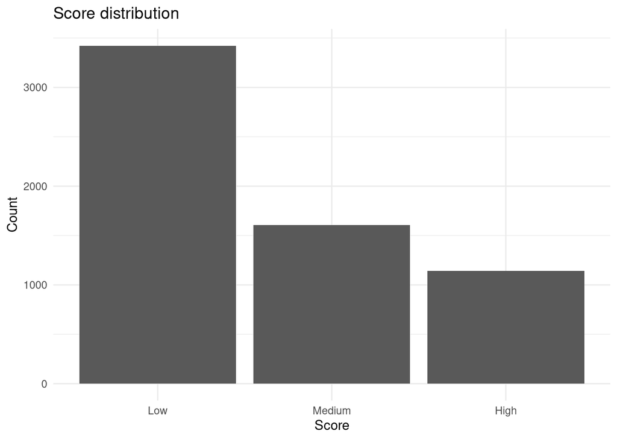

```r
# Set theme
ggplot2::theme_set(theme_minimal())

df %>%
  group_by(score) %>%
  count() %>%
  ggplot(aes(x = score, y = n)) +
    geom_col() +
    labs(x = "Score",
         y = "Count",
         title = "Score distribution")
```

Judges are often presented with two sets of scores from the COMPAS system – one that classifies people into High, Medium and Low risk, and a corresponding decile score. There is a clear downward trend in the decile scores as those scores increase for white defendants.

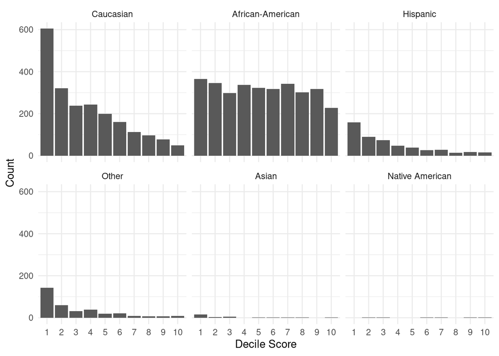

```r
df %>%
  ggplot(aes(ordered(decile_score))) +
          geom_bar() +
          facet_wrap(~race, nrow = 2) +
          labs(x = "Decile Score",
               y = "Count",
               Title = "Defendant's Decile Score")
```

## Modeling

After filtering out bad rows, our first question is whether there is a significant difference in COMPAS scores between races. To do so we need to change some variables into factors, and run a logistic regression, comparing low scores to high scores.

### Model building

```r
model_data <- function(data){

# Logistic regression model
lr_model <- glm(score ~ gender + age_cat + race + priors_count + crime + two_year_recid,
             family = "binomial", data = data)

# OLS, DV = score_num
ols_model1 <- lm(score_num ~ gender + age_cat + race + priors_count + crime + two_year_recid, data = data)

# OLS, DV = decile_score
ols_model2 <- lm(decile_score ~ gender + age_cat + race + priors_count + crime + two_year_recid, data = data)

# Extract model outcomes with confidence intervals
lr_est <- lr_model %>%
    tidy(conf.int = TRUE)

ols_est1 <- ols_model1 %>%
    tidy(conf.int = TRUE)

ols_est2 <- ols_model2 %>%
    tidy(conf.int = TRUE)

# AIC scores
lr_AIC <- AIC(lr_model)
ols_AIC1 <- AIC(ols_model1)
ols_AIC2 <- AIC(ols_model2)

list(lr_est, ols_est1, ols_est2,
     lr_AIC, ols_AIC1, ols_AIC2)

}
```

### Model comparisons

```r
glue("AIC score of logistic regression: {model_data(df)[4]}
      AIC score of OLS regression (with categorical DV):  {model_data(df)[5]}
      AIC score of OLS regression (with continuous DV): {model_data(df)[6]}")
```

```
## AIC score of logistic regression: 6192.40169473357
## AIC score of OLS regression (with categorical DV):  11772.1148541111
## AIC score of OLS regression (with continuous DV): 26779.9512226999
```

### Logistic regression model

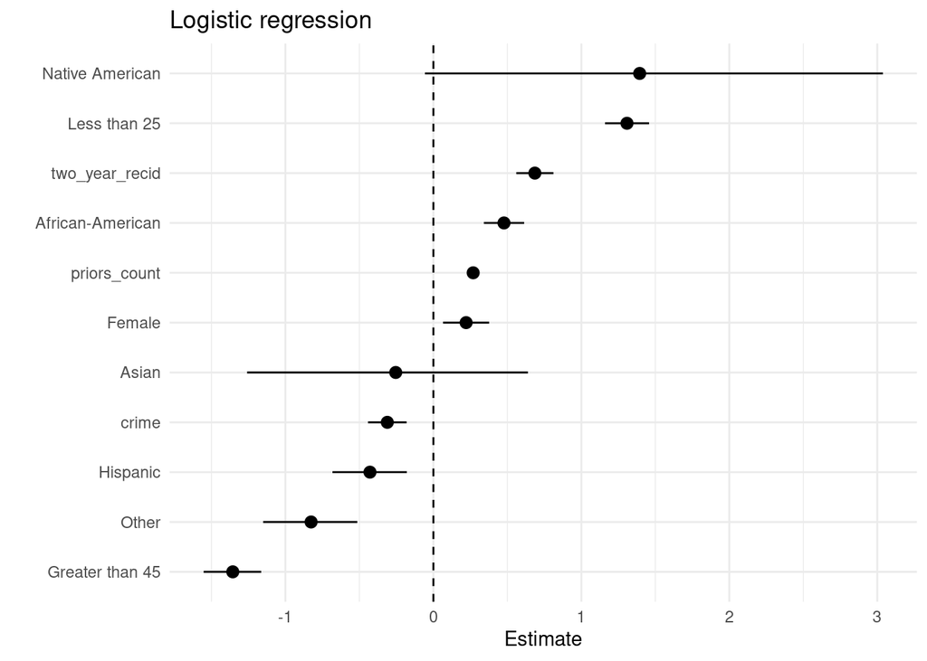

```r
lr_model <- model_data(df)[1] %>% data.frame()

lr_model %>%
  filter(term != "(Intercept)") %>%
  mutate(term = gsub("race|age_cat|gender|M","", term)) %>%
  ggplot(aes(x = fct_reorder(term, estimate), y = estimate, ymax = conf.high, ymin = conf.low)) +
  geom_pointrange() +
  coord_flip() +
  labs(y = "Estimate", x = "",
      title = "Logistic regression") +
  geom_hline(yintercept = 0, linetype = "dashed")
```

```r
interpret_estimate <- function(model){

    # Control
    intercept <- model$estimate[model$term == "(Intercept)"]
    control <- exp(intercept) / (1 + exp(intercept))

    # Likelihood
    model <- model %>% filter(term != "(Intercept)")

    model$likelihood <- (exp(model$estimate) / (1 - control + (control * exp(model$estimate))))

    return(model)
}
```

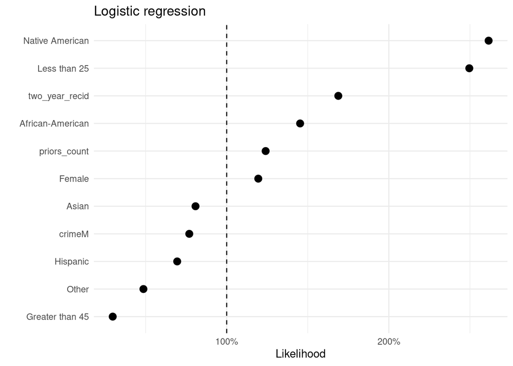

```r
interpret_estimate(lr_model) %>%
    mutate(term = gsub("race|age_cat|gender","", term)) %>%
    ggplot(aes(x = fct_reorder(term, likelihood), y = likelihood)) +
        geom_point(size = 3) +
        coord_flip() +
        labs(y = "Likelihood", x = "",
            title ="Logistic regression") +
        scale_y_continuous(labels = scales::percent_format(accuracy = 1)) +
        geom_hline(yintercept = 1, linetype = "dashed")
```